# Dead labor: classed, gendered, and racialized mortality inequities in the United States

```r
                                    "NH other caps", "NH other PBs", "NH other mans", "NH other wrks", "NH other NILFs")),
         class_educ=factor(ifelse(class=="Wrks" & (educ=="<HS" | educ=="HS"), "\u2264HS wrks",
                                 ifelse(class=="Wrks" & (educ=="Some college" | educ=="College+"), ">HS wrks",
                                        ifelse(class=="Mans" & (educ=="<HS" | educ=="HS"), "\u2264HS mans",
                                               ifelse(class=="Mans" & (educ=="Some college" | educ=="College+"), ">HS mans",
                                                      ifelse(class=="PBs" & (educ=="<HS" | educ=="HS"), "\u2264HS PBs",
                                                             ifelse(class=="PBs" & (educ=="Some college" | educ=="College+"), ">HS PBs",
                                                                    ifelse(class=="Caps" & (educ=="<HS" | educ=="HS"), "\u2264HS caps",
                                                                           ifelse(class=="Caps" & (educ=="Some college" | educ=="College+"), ">HS caps",
                                                                                  ifelse(class=="NILFs" & (educ=="<HS" | educ=="HS"), "\u2264HS NILFs",
                                                                                         ifelse(class=="NILFs" & (educ=="Some college" | educ=="College+"), ">HS NILFs", NA)))))))))),
                          levels=c(">HS caps", ">HS PBs", ">HS mans", ">HS wrks", ">HS NILFs",
                                   "\u2264HS caps", "\u2264HS PBs", "\u2264HS mans", "\u2264HS wrks", "\u2264HS NILFs")),
         class_sens=factor(ifelse(year<2001 | year>2003, NA, #identical to class variable
                                  ifelse(empstat==220, "NILFs",
                                         ifelse((empstat>=200 & empstat<=214) | (classwk>=20 & classwk<=34 & managers!=1), "Wrks",
                                                ifelse((classwk>=20 & classwk<=34 & managers==1), "Mans",
                                                       ifelse(classwk==40 & jobsecincorp==2, "Caps",
                                                              ifelse((classwk==40 & jobsecincorp==1) | classwk==50, "PBs", NA)))))),
                          levels=c("Caps", "PBs", "Mans", "Wrks", "NILFs")),
         class_occ=factor(ifelse(empstat==220, "NILFs",
                                 ifelse(empstat>=200 & empstat<=214, "Unemps",
                                        ifelse((year<2001 & classwk>=20 & classwk<=34 & occ1995>=900) | (year>=2001 & classwk2>=1 & classwk2<=4 & occ1995>=900), "Blue collar/farm",
                                               ifelse((year<2001 & classwk>=20 & classwk<=34 & occ1995>=600 & occ1995<900) | (year>=2001 & classwk2>=1 & classwk2<=4 & occ1995>=600 & occ1995<900), "Services",
                                                      ifelse((year<2001 & classwk>=20 & classwk<=34 & occ1995>=200 & occ1995<600) | (year>=2001 & classwk2>=1 & classwk2<=4 & occ1995>=200 & occ1995<600), "White collar",
                                                             ifelse((year<2001 & classwk>=20 & classwk<=34 & managers==1) | (year>=2001 & classwk2>=1 & classwk2<=4 & managers==1), "Mans",
                                                                    ifelse((year<2001 & classwk==41) | (year>=2001 & classwk2==5 & jobsecincorp==2), "Caps",
                                                                           ifelse((year<2001 & (classwk==42 | classwk==50)) | ((year>=2001 & classwk2==6) | (year>=2001 & classwk2==5 & jobsecincorp==1)), "PBs", NA)))))))),
                     levels=c("Caps", "PBs", "Mans", "White collar", "Services", "Blue collar/farm", "Unemps", "NILFs"))) -> dat_sub

#exclude respondent with negative follow-up time and those with missing weights
dat_sub %>%
  filter(time>=0 & !is.na(mortwt_f)) -> dat_sub

#make dataset without hispanic oversample for main analyses
dat_sub %>%
  filter(hispanic_oversample==0) -> dat_sub_no_hisp
```

# Missingness

Age missingness is in full dataset among years and samples of interest; missingness for other variables is among those ages 25-64

```r
#age in full dataset
merged %>%
  filter(eligstat==1 & (is.na(astatflg) | astatflg==1) & (year<1997 | (year>2000)) &
           !(year==1992 & substr(nhispid, 1, 4)==1991)) %>%
  mutate_at(.vars=(vars(-c(ucod_leading, mortwt, mortwtsa, psu, strata, nhispid, nhishid))), ~ifelse(. %in% c(91, 96, 97, 98, 99, 970, 980, 990, 7777, 8888, 9999), NA, .)) %>%
  summarise_at(vars('age'), funs(na=100*sum(is.na(.)/1233802))) %>%
  mutate(name='age') %>%
  relocate(na, .after=last_col()) -> dat_age_na

#other vars in subsetted dataset
dat_sub_no_hisp %>%
  summarise_at(vars(c('class', 'sex', 'race_h', 'educ', 'marital_tri', 'region')), funs(100*sum(is.na(.)/nrow(dat_sub_no_hisp)))) %>%
  tidyr::pivot_longer(class:region, values_to='na') -> dat_other_na

kable(bind_rows(dat_age_na, dat_other_na), digits=2, col.names=c("Variable", "Percent missing")) %>%
  kable_styling('striped')
```

| Variable | Percent missing |
| --- | --- |
| age | 0.09 |
| class | 1.66 |
| sex | 0.00 |
| race_h | 0.50 |
| educ | 0.76 |
| marital_tri | 0.38 |
| region | 0.00 |

# Descriptives

Weighted and excluding missingness unless otherwise noted

## Unweighted and stratified table one with missingness in variables of interest (aside from age and class)

```r
#vars of interest
vars <- c('sex', 'race_h', 'educ', 'marital_tri', 'region', 'age', 'year', 'time', 'dead')
catvars <- c("sex", 'dead')
nonorm <- c('age', 'year', 'time')

x <- CreateTableOne(data = dat_sub_no_hisp, vars=vars, factorVars=catvars, strata='class', includeNA=TRUE)
x <- print(x, printToggle=FALSE, noSpaces=TRUE, nonnormal=nonorm, test=FALSE)
kable(x) %>%
  kable_styling(c("striped", "condensed"))
```

|  | Caps | PBs | Mans | Wrks | NILFs |
| --- | --- | --- | --- | --- | --- |
| n | 19588 | 60624 | 85793 | 552657 | 202420 |
| sex = male (%) | 14288 (72.9) | 37126 (61.2) | 44919 (52.4) | 277002 (50.1) | 55661 (27.5) |
| race_h (%) |  |  |  |  |  |
| NH white | 16553 (84.5) | 48296 (79.7) | 68022 (79.3) | 373826 (67.6) | 129461 (64.0) |
| NH black | 785 (4.0) | 3730 (6.2) | 7501 (8.7) | 79567 (14.4) | 32758 (16.2) |
| Hispanic | 1219 (6.2) | 5899 (9.7) | 6129 (7.1) | 71661 (13.0) | 29071 (14.4) |
| NH other | 941 (4.8) | 2475 (4.1) | 3854 (4.5) | 25618 (4.6) | 9984 (4.9) |
| NA | 90 (0.5) | 224 (0.4) | 287 (0.3) | 1985 (0.4) | 1146 (0.6) |
| educ (%) |  |  |  |  |  |
| <HS | 1117 (5.7) | 8406 (13.9) | 2347 (2.7) | 73993 (13.4) | 56565 (27.9) |
| HS | 5121 (26.1) | 21506 (35.5) | 17769 (20.7) | 198011 (35.8) | 72634 (35.9) |
| Some college | 4791 (24.5) | 14427 (23.8) | 21989 (25.6) | 138713 (25.1) | 40999 (20.3) |
| College+ | 8513 (43.5) | 16039 (26.5) | 43549 (50.8) | 139584 (25.3) | 29963 (14.8) |
| NA | 46 (0.2) | 246 (0.4) | 139 (0.2) | 2356 (0.4) | 2259 (1.1) |
| marital_tri (%) |  |  |  |  |  |
| Married | 15673 (80.0) | 44411 (73.3) | 58272 (67.9) | 348125 (63.0) | 129334 (63.9) |
| Single | 1578 (8.1) | 6897 (11.4) | 13522 (15.8) | 102215 (18.5) | 29349 (14.5) |
| Widowed/divorced/separated | 2313 (11.8) | 9217 (15.2) | 13888 (16.2) | 101317 (18.3) | 42799 (21.1) |
| NA | 24 (0.1) | 99 (0.2) | 111 (0.1) | 1000 (0.2) | 938 (0.5) |
| region (%) |  |  |  |  |  |
| MW | 4515 (23.0) | 14780 (24.4) | 19763 (23.0) | 134264 (24.3) | 43432 (21.5) |
| NE | 4129 (21.1) | 9953 (16.4) | 17206 (20.1) | 105585 (19.1) | 38770 (19.2) |
| S | 6731 (34.4) | 19790 (32.6) | 28739 (33.5) | 190788 (34.5) | 73857 (36.5) |
| W | 4213 (21.5) | 16101 (26.6) | 20085 (23.4) | 122020 (22.1) | 46361 (22.9) |
| age (median [IQR]) | 45.00 [38.00, 53.00] | 44.00 [36.00, 53.00] | 41.00 [34.00, 49.00] | 40.00 [32.00, 49.00] | 48.00 [35.00, 59.00] |
| year (median [IQR]) | 1994.00 [1990.00, 2005.00] | 1993.00 [1989.00, 2003.00] | 1994.00 [1990.00, 2007.00] | 1994.00 [1990.00, 2007.00] | 1994.00 [1990.00, 2007.00] |
| time (median [IQR]) | 25.00 [12.00, 29.00] | 25.00 [14.00, 29.00] | 24.75 [11.00, 29.00] | 24.00 [11.00, 29.00] | 18.00 [9.00, 27.75] |
| dead = 1 (%) | 3358 (17.1) | 12808 (21.1) | 10820 (12.6) | 84277 (15.2) | 61627 (30.4) |

## Stratified table one

```r
dat_sub_no_hisp_svy <- svydesign(ids = ~ psu,
                         strata = ~ strata,
                         weights = ~ mortwt_f,
                         nest=TRUE,
                         data=dat_sub_no_hisp)

x <- svyCreateTableOne(data = dat_sub_no_hisp_svy, vars=vars, factorVars=catvars, strata='class', includeNA=FALSE)
x <- print(x, printToggle=FALSE, noSpaces=TRUE, nonnormal=nonorm, format='p', test=FALSE)
kable(x) %>%
  kable_styling(c("striped", "condensed"))
```

|  | Caps | PBs | Mans | Wrks | NILFs |
| --- | --- | --- | --- | --- | --- |
| n | 96525072.0 | 252023720.0 | 416873077.0 | 2538152519.0 | 891188317.0 |
| sex = male (%) | 72.5 | 61.0 | 54.1 | 52.3 | 30.4 |
| race_h (%) |  |  |  |  |  |
| NH white | 83.1 | 78.6 | 79.3 | 68.7 | 67.8 |
| NH black | 4.2 | 5.9 | 8.0 | 12.6 | 13.0 |
| Hispanic | 6.8 | 10.9 | 7.4 | 13.3 | 13.7 |
| NH other | 5.8 | 4.6 | 5.4 | 5.5 | 5.6 |
| educ (%) |  |  |  |  |  |
| <HS | 4.7 | 12.3 | 2.0 | 11.0 | 22.7 |
| HS | 23.3 | 33.2 | 17.1 | 32.5 | 34.8 |
| Some college | 26.3 | 26.4 | 25.3 | 27.8 | 24.1 |
| College+ | 45.7 | 28.2 | 55.6 | 28.7 | 18.4 |
| marital_tri (%) |  |  |  |  |  |
| Married | 80.9 | 72.6 | 70.4 | 64.3 | 65.8 |
| Single | 8.3 | 12.4 | 15.3 | 19.2 | 15.0 |
| Widowed/divorced/separated | 10.9 | 15.1 | 14.2 | 16.5 | 19.1 |
| region (%) |  |  |  |  |  |
| MW | 23.0 | 23.2 | 23.4 | 24.5 | 21.4 |
| NE | 19.3 | 16.5 | 19.9 | 18.9 | 18.3 |
| S | 36.4 | 34.0 | 34.3 | 35.4 | 38.1 |
| W | 21.3 | 26.3 | 22.3 | 21.2 | 22.2 |
| age (median [IQR]) | 46.00 [38.00, 54.00] | 45.00 [36.00, 53.00] | 42.00 [34.00, 51.00] | 41.00 [32.00, 50.00] | 49.00 [36.00, 59.00] |
| year (median [IQR]) | 2005.00 [1994.00, 2012.00] | 2003.00 [1992.00, 2010.00] | 2006.00 [1994.00, 2013.00] | 2005.00 [1994.00, 2012.00] | 2006.00 [1994.00, 2012.00] |
| time (median [IQR]) | 14.00 [8.00, 24.00] | 15.50 [9.00, 26.00] | 13.75 [7.00, 24.00] | 14.00 [7.75, 24.25] | 12.00 [6.75, 19.00] |
| dead = 1 (%) | 10.4 | 14.2 | 7.6 | 9.5 | 21.0 |

## Stratified class composition of gender-races

```r
x <- svyCreateTableOne(data = subset(dat_sub_no_hisp_svy, !is.na(race_h)), vars='class', factorVars='class', strata='race_h_sex', includeNA=FALSE)
x <- print(x, printToggle=FALSE, noSpaces=TRUE, nonnormal=nonorm, format='p', test=FALSE)
kable(x[2:7,]) %>%
  kable_styling(c("striped", "condensed"))
```

|  | Hispanic female | Hispanic male | NH black female | NH black male | NH other female | NH other male | NH white female | NH white male |
| --- | --- | --- | --- | --- | --- | --- | --- | --- |
| class (%) |  |  |  |  |  |  |  |  |
| Caps | 0.6 | 1.9 | 0.5 | 1.3 | 1.6 | 3.3 | 1.5 | 4.0 |
| PBs | 4.3 | 6.2 | 2.0 | 4.3 | 4.1 | 6.1 | 5.1 | 8.3 |
| Mans | 5.5 | 6.2 | 7.2 | 6.4 | 8.8 | 11.1 | 9.8 | 12.6 |
| Wrks | 53.6 | 75.0 | 62.9 | 68.7 | 55.0 | 67.0 | 55.8 | 62.3 |
| NILFs | 36.0 | 10.7 | 27.4 | 19.3 | 30.4 | 12.5 | 27.8 | 12.8 |

## Proportions in classes over time

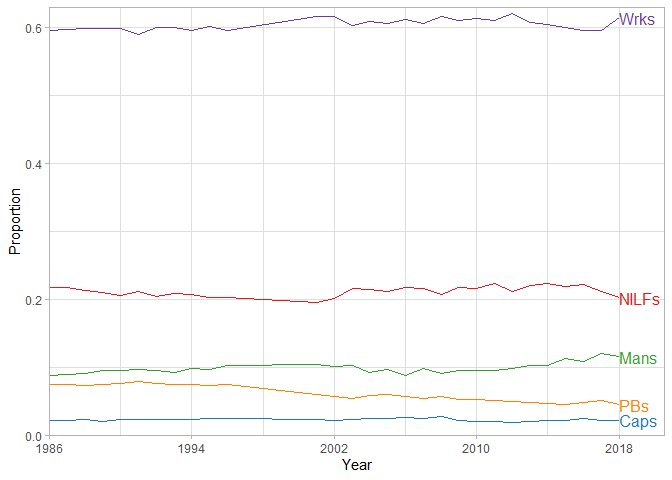

```r
dat_sub_no_hisp %>%
  filter(!is.na(class)) %>%
  group_by(class, year) %>%
  summarise(n = sum(mortwt_f)) %>%
  ungroup() %>%
  group_by(year) %>%
  mutate(prop = n / sum(n)) -> propped

ggplot(propped, aes(x=year, y=prop, group=class, color=class, label=class)) +
  geom_dl(method='last.qp') +
  geom_line() +
  scale_color_manual(values=brewer.pal(n = 12, name = "Paired")[c(2,8,4,10,6)]) +
  scale_x_continuous(breaks=c(1986, 1994, 2002, 2010, 2018), expand=expansion(mult=c(0,0.08))) +
  scale_y_continuous(limits=c(0, 0.63), expand=expansion(mult=c(0,0))) +
  xlab("Year") +
  ylab("Proportion") +
  theme_light() +
  theme(legend.position = "none")
```

## Family income distribution across classes from 2007-2018

Income coding inconsistent prior to 2007. Unadjusted for inflation. Row label shows lower bound of category.

```r
x <- svyCreateTableOne(data = subset(dat_sub_no_hisp_svy, year>=2007), vars='incimp1_rev', factorVars='incimp1_rev', strata='class', includeNA=FALSE)
x <- print(x, printToggle=FALSE, noSpaces=TRUE, nonnormal=nonorm, format='p', test=FALSE)
row.names(x)[3:23] <- c(paste0(seq(0,95,5), "k"),">=100k")
kable(x[3:23,]) %>%
  kable_styling(c("striped", "condensed"))
```

|  | Caps | PBs | Mans | Wrks | NILFs |
| --- | --- | --- | --- | --- | --- |
| 0k | 0.6 | 1.8 | 0.3 | 1.6 | 4.2 |
| 5k | 0.5 | 2.6 | 0.3 | 1.9 | 7.8 |
| 10k | 0.9 | 4.2 | 0.6 | 2.9 | 8.4 |
| 15k | 1.3 | 4.3 | 0.8 | 3.5 | 7.2 |
| 20k | 1.8 | 5.4 | 1.1 | 4.4 | 6.9 |
| 25k | 1.5 | 4.9 | 1.5 | 4.3 | 5.6 |
| 30k | 2.6 | 5.0 | 2.0 | 4.9 | 5.6 |
| 35k | 2.8 | 5.1 | 2.2 | 4.6 | 4.9 |
| 40k | 3.7 | 5.3 | 2.7 | 4.9 | 4.7 |
| 45k | 2.5 | 3.8 | 2.7 | 4.3 | 3.8 |
| 50k | 4.5 | 5.2 | 3.3 | 4.9 | 4.2 |
| 55k | 2.3 | 3.1 | 2.7 | 3.6 | 2.6 |
| 60k | 3.5 | 4.1 | 3.3 | 4.7 | 3.4 |
| 65k | 3.1 | 3.1 | 2.8 | 3.5 | 2.3 |
| 70k | 3.4 | 3.3 | 3.7 | 3.9 | 2.8 |
| 75k | 3.9 | 2.9 | 3.3 | 3.5 | 2.2 |
| 80k | 3.8 | 3.1 | 4.0 | 3.6 | 2.5 |
| 85k | 2.1 | 2.1 | 3.1 | 2.6 | 1.4 |
| 90k | 3.2 | 2.5 | 3.2 | 3.1 | 1.8 |
| 95k | 2.0 | 1.8 | 2.8 | 2.3 | 1.2 |
| >=100k | 50.1 | 26.5 | 53.5 | 27.0 | 16.4 |

## Number of employees at work across classes from 2001-2018

```r
x <- svyCreateTableOne(data = subset(dat_sub_no_hisp_svy, year>=2001 & numemps!=0 & class!="NILFs"), vars='numemps', factorVars='numemps', strata='class', includeNA=FALSE)
x <- print(x, printToggle=FALSE, noSpaces=TRUE, nonnormal=nonorm, format='p', test=FALSE)
row.names(x)[3:10] <- c("1-9", "10-24", "25-49", "50-99", "100-249", "250-499", "500-999", "1000+")
kable(x[3:10,1:4]) %>%
  kable_styling(c("striped", "condensed"))
```

|  | Caps | PBs | Mans | Wrks |
| --- | --- | --- | --- | --- |
| 1-9 | 81.5 | 95.3 | 17.6 | 18.9 |
| 10-24 | 10.3 | 2.6 | 13.7 | 14.9 |
| 25-49 | 4.5 | 0.8 | 11.7 | 12.4 |
| 50-99 | 1.9 | 0.5 | 11.1 | 12.0 |
| 100-249 | 1.1 | 0.3 | 13.1 | 13.9 |
| 250-499 | 0.3 | 0.2 | 8.4 | 7.7 |
| 500-999 | 0.2 | 0.1 | 7.0 | 5.9 |
| 1000+ | 0.2 | 0.2 | 17.3 | 14.4 |

## Reason not in labor force

### Main reason for not working last week

Variable only available from 2004-on.

```r
x <- svyCreateTableOne(data = subset(dat_sub_no_hisp_svy, year>=2004 & empstat==220 & whynowk2!=0), vars='whynowk2', factorVars='whynowk2', includeNA=FALSE)
x <- print(x, printToggle=FALSE, noSpaces=TRUE, nonnormal=nonorm, format='p', test=FALSE)
row.names(x)[3:12] <- c("Keeping house", "Going to school", "Retired", "Unable to work for health reasons", "Disabled", "On layoff", "On planned vacation", "On family leave", "Have job/contract; off season", "Other")
kable(x[3:12,], digits=2, col.names="Percent") %>%
  kable_styling("striped")
```

|  | Percent |
| --- | --- |
| Keeping house | 34.0 |
| Going to school | 4.4 |
| Retired | 17.7 |
| Unable to work for health reasons | 3.2 |
| Disabled | 33.1 |
| On layoff | 2.1 |
| On planned vacation | 0.8 |
| On family leave | 0.4 |
| Have job/contract; off season | 0.8 |
| Other | 3.5 |

### Limited in kind/amount of work can do

Variable only available from 1997-on.

```r
x <- svyCreateTableOne(data = subset(dat_sub_no_hisp_svy, year>=1997), vars='lamtwrk', factorVars='lamtwrk', strata='empstat', includeNA=FALSE)
x <- print(x, printToggle=FALSE, noSpaces=TRUE, nonnormal=nonorm, format='p', test=FALSE)
row.names(x)[3:5] <- c("Not limited", "Limited", "Unable to work")
kable(x[3:5,], col.names=c("Working for pay", "Working w/o pay", "With job, but not at work", "Not employed", "NILF")) %>%
  kable_styling("striped")
```

|  | Working for pay | Working w/o pay | With job, but not at work | Not employed | NILF |
| --- | --- | --- | --- | --- | --- |
| Not limited | 96.9 | 90.9 | 88.1 | 88.0 | 62.8 |
| Limited | 2.6 | 4.9 | 4.6 | 6.0 | 5.9 |
| Unable to work | 0.5 | 4.2 | 7.3 | 5.9 | 31.3 |

# Class and all-cause mortality

```r
plotted <- function(datted=kapped, bottom=0.5){

  survplot <- ggsurvplot(datted,
                         size=0.35,
                         conf.int = T,
                         ylim=c(bottom, 1.0),
                         xlim=c(0, max(datted$time)),
                         axes.offset=F,
                         censor=F)
  survplot$plot +
    scale_color_manual(values=brewer.pal(n = 12, name = "Paired")[c(2,8,4,10,6)]) +
    scale_fill_manual(values=brewer.pal(n = 12, name = "Paired")[c(2,8,4,10,6)]) +
    geom_dl(aes(label=class, group=strata, color=strata), method='last.qp') +
    scale_x_continuous(limits=c(0, 34), breaks=seq(1, 34, 3), expand=expansion(mult=c(0,0.09))) +
    scale_y_continuous(limits=c(bottom, 1.0), expand=expansion(mult=c(0,0))) +
    ylab("Probability of survival") +
    xlab("Follow-up time (years)") +
    theme_light() +
    theme(legend.position="none")

}

#survdiff function
survdiffed <- function(datted=kapped, timed=34){

  #end of f/u
  point <- summary(datted,times=timed)

  #pb-cap
  pb <- 100*(point$surv[2] - point$surv[1])
  pb_lower <- 100*(pb/100 - 1.96*sqrt(point$std.err[2]^2 + point$std.err[1]^2))
  pb_upper <- 100*(pb/100 + 1.96*sqrt(point$std.err[2]^2 + point$std.err[1]^2))

  #mc-cap
  mc <- 100*(point$surv[3] - point$surv[1])
  mc_lower <- 100*(mc/100 - 1.96*sqrt(point$std.err[3]^2 + point$std.err[1]^2))
  mc_upper <- 100*(mc/100 + 1.96*sqrt(point$std.err[3]^2 + point$std.err[1]^2))

  #worker-cap
  wc <- 100*(point$surv[4] - point$surv[1])
  wc_lower <- 100*(wc/100 - 1.96*sqrt(point$std.err[4]^2 + point$std.err[1]^2))
  wc_upper <- 100*(wc/100 + 1.96*sqrt(point$std.err[4]^2 + point$std.err[1]^2))

  #nilf-cap
  nc <- 100*(point$surv[5] - point$surv[1])
  nc_lower <- 100*(nc/100 - 1.96*sqrt(point$std.err[5]^2 + point$std.err[1]^2))
  nc_upper <- 100*(nc/100 + 1.96*sqrt(point$std.err[5]^2 + point$std.err[1]^2))

  rbind(c(pb, pb_lower, pb_upper), c(mc, mc_lower, mc_upper), c(wc, wc_lower, wc_upper), c(nc, nc_lower, nc_upper))

}

#survdiff function for groups
survdiffed_group <- function(datted=kapped, timed=30){

  #end of f/u
  point <- summary(datted,times=timed)

  #pb-cap
  pb <- 100*(point$surv[2] - point$surv[1])
  pb_lower <- 100*(pb/100 - 1.96*sqrt(point$std.err[2]^2 + point$std.err[1]^2))
  pb_upper <- 100*(pb/100 + 1.96*sqrt(point$std.err[2]^2 + point$std.err[1]^2))

  #mc-cap
  mc <- 100*(point$surv[3] - point$surv[1])
  mc_lower <- 100*(mc/100 - 1.96*sqrt(point$std.err[3]^2 + point$std.err[1]^2))
  mc_upper <- 100*(mc/100 + 1.96*sqrt(point$std.err[3]^2 + point$std.err[1]^2))

  #worker-cap
  wc <- 100*(point$surv[4] - point$surv[1])
  wc_lower <- 100*(wc/100 - 1.96*sqrt(point$std.err[4]^2 + point$std.err[1]^2))
  wc_upper <- 100*(wc/100 + 1.96*sqrt(point$std.err[4]^2 + point$std.err[1]^2))

  #nilf-cap
  nc <- 100*(point$surv[5] - point$surv[1])
  nc_lower <- 100*(nc/100 - 1.96*sqrt(point$std.err[5]^2 + point$std.err[1]^2))
  nc_upper <- 100*(nc/100 + 1.96*sqrt(point$std.err[5]^2 + point$std.err[1]^2))

  #cap2-cap
  cap2 <- 100*(point$surv[6] - point$surv[1])
  cap2_lower <- 100*(cap2/100 - 1.96*sqrt(point$std.err[6]^2 + point$std.err[1]^2))
  cap2_upper <- 100*(cap2/100 + 1.96*sqrt(point$std.err[6]^2 + point$std.err[1]^2))

  #pb2-cap
  pb2 <- 100*(point$surv[7] - point$surv[1])
  pb2_lower <- 100*(pb2/100 - 1.96*sqrt(point$std.err[7]^2 + point$std.err[1]^2))
  pb2_upper <- 100*(pb2/100 + 1.96*sqrt(point$std.err[7]^2 + point$std.err[1]^2))

  #man2-cap
  man2 <- 100*(point$surv[8] - point$surv[1])
  man2_lower <- 100*(man2/100 - 1.96*sqrt(point$std.err[8]^2 + point$std.err[1]^2))
  man2_upper <- 100*(man2/100 + 1.96*sqrt(point$std.err[8]^2 + point$std.err[1]^2))

  #wrk2-cap
  wrk2 <- 100*(point$surv[9] - point$surv[1])
  wrk2_lower <- 100*(wrk2/100 - 1.96*sqrt(point$std.err[9]^2 + point$std.err[1]^2))
  wrk2_upper <- 100*(wrk2/100 + 1.96*sqrt(point$std.err[9]^2 + point$std.err[1]^2))

  #nilf2-cap
  nilf2 <- 100*(point$surv[10] - point$surv[1])
  nilf2_lower <- 100*(nilf2/100 - 1.96*sqrt(point$std.err[10]^2 + point$std.err[1]^2))
  nilf2_upper <- 100*(nilf2/100 + 1.96*sqrt(point$std.err[10]^2 + point$std.err[1]^2))

  rbind(c(pb, pb_lower, pb_upper), c(mc, mc_lower, mc_upper), c(wc, wc_lower, wc_upper), c(nc, nc_lower, nc_upper),
        c(cap2, cap2_lower, cap2_upper), c(pb2, pb2_lower, pb2_upper), c(man2, man2_lower, man2_upper), c(wrk2, wrk2_lower, wrk2_upper), c(nilf2, nilf2_lower, nilf2_upper))

}

#survdiff function for worker subdivision
survdiffed_sub <- function(datted=kapped, timed=30){

  #end of f/u
  point <- summary(datted,times=timed)

  #pb-cap
  pb <- 100*(point$surv[2] - point$surv[1])
  pb_lower <- 100*(pb/100 - 1.96*sqrt(point$std.err[2]^2 + point$std.err[1]^2))
  pb_upper <- 100*(pb/100 + 1.96*sqrt(point$std.err[2]^2 + point$std.err[1]^2))

  #mc-cap
  mc <- 100*(point$surv[3] - point$surv[1])
  mc_lower <- 100*(mc/100 - 1.96*sqrt(point$std.err[3]^2 + point$std.err[1]^2))
  mc_upper <- 100*(mc/100 + 1.96*sqrt(point$std.err[3]^2 + point$std.err[1]^2))

  #whitecollar-cap
  wc <- 100*(point$surv[4] - point$surv[1])
  wc_lower <- 100*(wc/100 - 1.96*sqrt(point$std.err[4]^2 + point$std.err[1]^2))
  wc_upper <- 100*(wc/100 + 1.96*sqrt(point$std.err[4]^2 + point$std.err[1]^2))

  #services-cap
  servs <- 100*(point$surv[5] - point$surv[1])
  servs_lower <- 100*(servs/100 - 1.96*sqrt(point$std.err[5]^2 + point$std.err[1]^2))
  servs_upper <- 100*(servs/100 + 1.96*sqrt(point$std.err[5]^2 + point$std.err[1]^2))

  #bluecollar-cap
  bc <- 100*(point$surv[6] - point$surv[1])
  bc_lower <- 100*(bc/100 - 1.96*sqrt(point$std.err[6]^2 + point$std.err[1]^2))
  bc_upper <- 100*(bc/100 + 1.96*sqrt(point$std.err[6]^2 + point$std.err[1]^2))

  #pb2-cap
  unemp <- 100*(point$surv[7] - point$surv[1])
  unemp_lower <- 100*(unemp/100 - 1.96*sqrt(point$std.err[7]^2 + point$std.err[1]^2))
  unemp_upper <- 100*(unemp/100 + 1.96*sqrt(point$std.err[7]^2 + point$std.err[1]^2))

  #man2-cap
  nilf <- 100*(point$surv[8] - point$surv[1])
  nilf_lower <- 100*(nilf/100 - 1.96*sqrt(point$std.err[8]^2 + point$std.err[1]^2))
  nilf_upper <- 100*(nilf/100 + 1.96*sqrt(point$std.err[8]^2 + point$std.err[1]^2))

  rbind(c(pb, pb_lower, pb_upper), c(mc, mc_lower, mc_upper), c(wc, wc_lower, wc_upper), c(servs, servs_lower, servs_upper),
        c(bc, bc_lower, bc_upper), c(unemp, unemp_lower, unemp_upper), c(nilf, nilf_lower, nilf_upper))

}

#tidying regression output function
tidy_n <- function(modded=mod, rows=1:4, cols=c(1,2,7,8), bind=binded, nad=3, captioned="Ref: capitalist") {
  tidydf <- cbind(tidy(modded, exponentiate=T, conf.int=T)[rows, cols], bind)
  tidydf$N <- c(length(modded$residuals), rep(NA, nad))
  kable(tidydf, digits=c(2,2,2,2,1,1,1,1), caption=captioned, col.names=c(" ", "HR", "Lower", "Upper", "SD", "Lower", "Upper", "N")) %>%
    kable_styling("striped") %>%
    add_header_above(c(" ", "HR"=3, "SD per 100 at end of f/u"=3, " "))
}
```

## Overall

### Less-adjusted (age, gender, year)

#### Distribution of IPW

```r
dat_sub_no_hisp %>%
  filter(!is.na(class) & !is.na(age)) %>%
  mutate(sw=ipwpoint(exposure=class,
                     family="multinomial",
                     link="logit",
                     numerator=~1,
                     denominator=~rcs(age, 3) + sex + rcs(year, 5),
                     data = subset(dat_sub_no_hisp, !is.na(class) & !is.na(age)),
                     weights=mortwt_f,
                     trace=FALSE,
                     maxit=1000)$ipw.weights,
         sw_f=sw*mortwt_f)  -> dat_sub_no_hisp_overall

summary(dat_sub_no_hisp_overall$sw)
```

```
##    Min. 1st Qu.  Median    Mean 3rd Qu.    Max.
##  0.3345  0.8490  0.9532  0.9901  1.0513  6.2257
```

#### Covariate balance after weighting

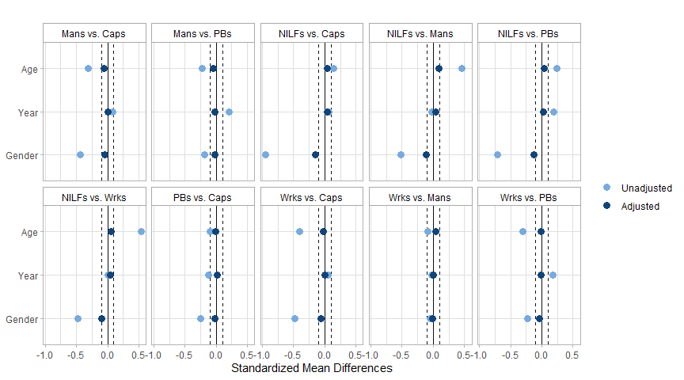

```r
covs <- subset(dat_sub_no_hisp_overall, select=c('age', 'year', 'sex'))

love.plot(covs,
          treat=dat_sub_no_hisp_overall$class,
          weights=dat_sub_no_hisp_overall$sw,
          threshold=c(m=0.1),
          binary='std',
          which=.all) +
  facet_wrap(~treat, nrow=2) +
  scale_color_manual(values=c("#77AADD", "#114477")) +
  theme_light() +
  theme(legend.title=element_blank(), plot.title=element_blank(),
        strip.background=element_rect(color="darkgrey", fill=NA), strip.text=element_text(color="black")) +
  scale_y_discrete(labels=rev(c("Age", "Year", "Gender")))
```

```r
kapped <- survfit(Surv(time,dead)~class, robust=T, w=sw_f, data=dat_sub_no_hisp_overall, se=T)
mod <- coxph(Surv(time,dead)~class, robust=T, w=sw_f, data=dat_sub_no_hisp_overall)
binded <- survdiffed()
```

#### IPW survival plot

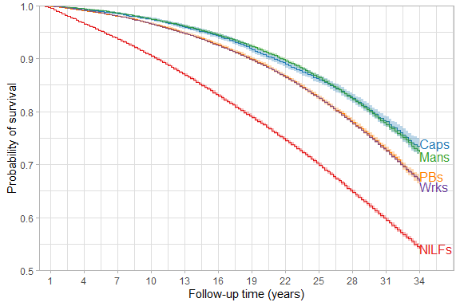

```r
plotted()
```

```r
ggsave("overall_survival.png", dpi=600, height=4, width=6)
```

#### IPW survival difference and hazard ratio

```r
tidy_n()
```

Ref: capitalist

|  | HR | HR Lower | HR Upper | SD per 100 at end of f/u SD | SD per 100 at end of f/u Lower | SD per 100 at end of f/u Upper | N |
| --- | --- | --- | --- | --- | --- | --- | --- |
| classPBs | 1.28 | 1.21 | 1.36 | -6.5 | -8.2 | -4.7 | 921082 |
| classMans | 0.99 | 0.94 | 1.05 | -1.1 | -2.8 | 0.6 |  |
| classWrks | 1.30 | 1.23 | 1.37 | -6.6 | -8.2 | -5.1 |  |
| classNILFs | 2.57 | 2.43 | 2.71 | -19.3 | -20.9 | -17.6 |  |

### More-adjusted (age, gender, year, education, marital status, region, and racialized group)

#### Distribution of IPW

Truncated at 0.5% and 99.5%.

```r
dat_sub_no_hisp %>%
  filter(!is.na(class) & !is.na(age) & !is.na(educ) & !is.na(marital_tri) & !is.na(region) & !is.na(race_h)) %>%
  mutate(sw=ipwpoint(exposure=class,
                     family="multinomial",
                     link="logit",
                     numerator=~1,
                     denominator=~rcs(age, 3) + sex + rcs(year, 5) + educ + marital_tri + region + race_h,
                     data = subset(dat_sub_no_hisp, !is.na(class) & !is.na(age) & !is.na(educ) & !is.na(marital_tri) & !is.na(region) & !is.na(race_h)),
                     weights=mortwt_f,
                     trace=FALSE,
                     maxit=1000,
                     trunc=0.005)$weights.trunc,
         sw_f=sw*mortwt_f)  -> dat_sub_no_hisp_overall_adj

summary(dat_sub_no_hisp_overall_adj$sw)
```

```
##    Min. 1st Qu.  Median    Mean 3rd Qu.    Max.
##  0.2793  0.7964  0.9183  0.9817  1.0791  3.8197
```

#### Covariate balance after weighting

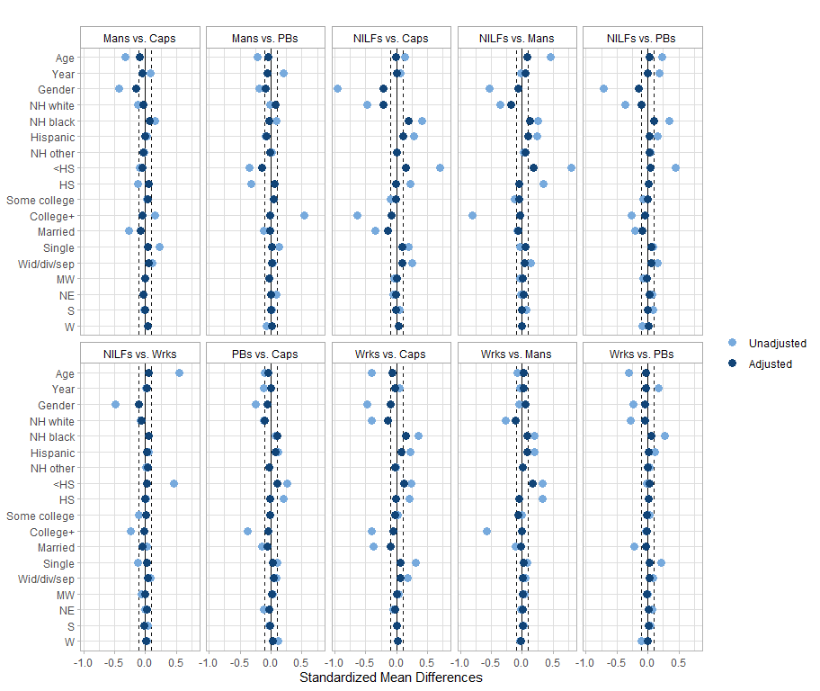

```r
covs <- subset(dat_sub_no_hisp_overall_adj, select=c('age', 'year', 'sex', 'race_h', 'educ', 'marital_tri', 'region'))

love.plot(covs,
          treat=dat_sub_no_hisp_overall_adj$class,
          weights=dat_sub_no_hisp_overall_adj$sw,
          threshold=c(m=0.1),
          binary='std',
          which=.all) +
  facet_wrap(~treat, nrow=2) +
  scale_color_manual(values=c("#77AADD", "#114477")) +
  theme_light() +
  theme(legend.title=element_blank(), plot.title=element_blank(),
        strip.background=element_rect(color="darkgrey", fill=NA), strip.text=element_text(color="black")) +
  scale_y_discrete(labels=rev(c("Age", "Year", "Gender", 'NH white', "NH black", "Hispanic", "NH other",
                                "<HS", "HS", "Some college", "College+", "Married", "Single", "Wid/div/sep", "MW", "NE", "S", "W")))
```

```r
kapped <- survfit(Surv(time,dead)~class, robust=T, w=sw_f, data=dat_sub_no_hisp_overall_adj, se=T)
mod <- coxph(Surv(time,dead)~class, robust=T, w=sw_f, data=dat_sub_no_hisp_overall_adj)
binded <- survdiffed()
```

#### IPW survival plot

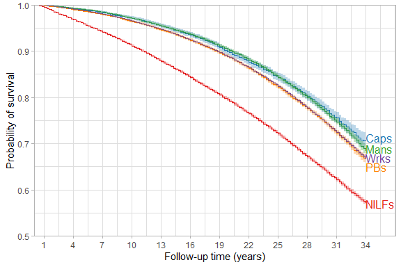

```r
plotted()
```

```r
ggsave("overall_survival_adj.png", dpi=600, height=4, width=6)
```

#### IPW survival difference and hazard ratio

```r
tidy_n()
```

Ref: capitalist

|  | HR | HR Lower | HR Upper | SD per 100 at end of f/u SD | SD per 100 at end of f/u Lower | SD per 100 at end of f/u Upper | N |
| --- | --- | --- | --- | --- | --- | --- | --- |
| classPBs | 1.17 | 1.10 | 1.24 | -3.9 | -5.9 | -1.9 | 911339 |
| classMans | 1.02 | 0.95 | 1.08 | -2.0 | -4.1 | 0.1 |  |
| classWrks | 1.15 | 1.09 | 1.22 | -3.8 | -5.6 | -2.0 |  |
| classNILFs | 2.08 | 1.97 | 2.21 | -13.4 | -15.3 | -11.5 |  |

## Class-by-year stratification - 1986-1996 waves w/ f/u through end of 2004 vs 2001-2018 waves w/ f/u through end of 2019

### Less-adjusted

#### Distribution of IPW

##### 1986-1996

```r
dat_sub_no_hisp %>%
  filter(year<=1996 & !is.na(class) & !is.na(age)) %>%
  mutate(sw=ipwpoint(exposure=class,
                     family="multinomial",
                     link="logit",
                     numerator=~1,
                     denominator=~rcs(age, 3) + sex + rcs(year, 3),
                     data = subset(dat_sub_no_hisp, year<=1996 & !is.na(class) & !is.na(age)),
                     weights=mortwt_f,
                     maxit=1000,
                     trace=FALSE)$ipw.weights,
         sw_f=sw*mortwt_f,
         period="1986-1996 with follow-up through 2004")  -> dat_sub_no_hisp_1986

summary(dat_sub_no_hisp_1986$sw)
```

```
##    Min. 1st Qu.  Median    Mean 3rd Qu.    Max.
##  0.2956  0.8247  0.9391  0.9979  1.0362  6.4323
```

##### 2001-2018

```r
dat_sub_no_hisp %>%
  filter(year>=2001 & !is.na(class) & !is.na(age)) %>%
  mutate(sw=ipwpoint(exposure=class,
                     family="multinomial",
                     link="logit",
                     numerator=~1,
                     denominator=~rcs(age, 3) + sex + rcs(year, 3),
                     data = subset(dat_sub_no_hisp, year>=2001 & !is.na(class) & !is.na(age)),
                     weights=mortwt_f,
                     maxit=1000,
                     trace=FALSE)$ipw.weights,
         sw_f=sw*mortwt_f,
         period="2001-2018 with follow-up through 2019")  -> dat_sub_no_hisp_2001

summary(dat_sub_no_hisp_2001$sw)
```

```
##    Min. 1st Qu.  Median    Mean 3rd Qu.    Max.
##  0.3551  0.8556  0.9421  0.9990  1.0758  5.5327
```

```r
#early
kapped_early <- survfit(Surv(time_86_96_05, dead_86_96_05)~class + period, robust=T, w=sw_f, data=dat_sub_no_hisp_1986, se=T) #period allows for faceting but doesnt affect ests
mod_early <- coxph(Surv(time_86_96_05, dead_86_96_05)~class, robust=T, w=sw_f, data=dat_sub_no_hisp_1986)
binded_early <- survdiffed(kapped_early, timed=19)

#late
kapped_late <- survfit(Surv(time,dead)~class + period, robust=T, w=sw_f, data=dat_sub_no_hisp_2001, se=T)
mod_late <- coxph(Surv(time,dead)~class, robust=T, w=sw_f, data=dat_sub_no_hisp_2001)
binded_late <- survdiffed(kapped_late, timed=19)
```

#### IPW survival plots

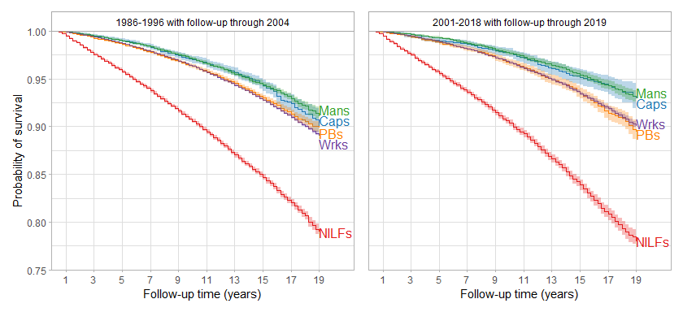

```r
plotted(kapped_early) +
  facet_wrap(~period) +
  scale_y_continuous(limits=c(0.75, 1.0), expand=expansion(mult=c(0,0))) +
  scale_x_continuous(limits=c(0, 19), breaks=seq(1, 19, 2), expand=expansion(mult=c(0,0.13))) +
  theme(panel.grid.minor.x = element_blank(), strip.background=element_rect(color="darkgrey", fill=NA), strip.text=element_text(color="black")) +
plotted(kapped_late) +
  facet_wrap(~period) +
  scale_y_continuous(limits=c(0.75, 1.0), expand=expansion(mult=c(0,0))) +
  scale_x_continuous(limits=c(0, 19), breaks=seq(1, 19, 2), expand=expansion(mult=c(0,0.13))) +
  theme(panel.grid.minor.x = element_blank(), strip.background=element_rect(color="darkgrey", fill=NA), strip.text=element_text(color="black"),
        axis.title.y=element_blank(), axis.text.y=element_blank(), axis.ticks.y=element_blank())
```

```r
ggsave("change_over_time.png", dpi=600, height=4, width=8.75)
```

#### IPW survival difference and hazard ratio

```r
tidy_n(modded=mod_early, bind=binded_early, captioned="Ref: capitalists (1986-1996 subset)")
```

Ref: capitalists (1986-1996 subset)

|  | HR | HR Lower | HR Upper | SD per 100 at end of f/u SD | SD per 100 at end of f/u Lower | SD per 100 at end of f/u Upper | N |
| --- | --- | --- | --- | --- | --- | --- | --- |
| classPBs | 1.17 | 1.06 | 1.30 | -0.1 | -1.8 | 1.6 | 571372 |
| classMans | 0.95 | 0.86 | 1.06 | 1.2 | -0.6 | 2.9 |  |
| classWrks | 1.22 | 1.11 | 1.34 | -0.9 | -2.5 | 0.7 |  |
| classNILFs | 2.78 | 2.52 | 3.06 | -11.0 | -12.7 | -9.3 |  |

```r
tidy_n(modded=mod_late, bind=binded_late, captioned="Ref: capitalists (2001-2018 subset)")
```

Ref: capitalists (2001-2018 subset)

|  | HR | HR Lower | HR Upper | SD per 100 at end of f/u SD | SD per 100 at end of f/u Lower | SD per 100 at end of f/u Upper | N |
| --- | --- | --- | --- | --- | --- | --- | --- |
| classPBs | 1.38 | 1.16 | 1.65 | -3.5 | -5.2 | -1.7 | 349710 |
| classMans | 0.94 | 0.79 | 1.11 | 0.2 | -1.3 | 1.7 |  |
| classWrks | 1.36 | 1.16 | 1.59 | -2.9 | -4.3 | -1.4 |  |
| classNILFs | 3.80 | 3.25 | 4.45 | -15.0 | -16.6 | -13.4 |  |

### More-adjusted

#### Distribution of IPW

Truncated at 0.5% and 99.5%.

##### 1986-1996

```r
dat_sub_no_hisp %>%
  filter(year<=1996 & !is.na(class) & !is.na(age) & !is.na(educ) & !is.na(marital_tri) & !is.na(region) & !is.na(race_h)) %>%
  mutate(sw=ipwpoint(exposure=class,
                     family="multinomial",
                     link="logit",
                     numerator=~1,
                     denominator=~rcs(age, 3) + sex + rcs(year, 3) + educ + marital_tri + region + race_h,
                     data = subset(dat_sub_no_hisp, year<=1996 & !is.na(class) & !is.na(age) & !is.na(educ) & !is.na(marital_tri) & !is.na(region) & !is.na(race_h)),
                     weights=mortwt_f,
                     trace=FALSE,
                     maxit=1000,
                     trunc=0.005)$weights.trunc,
         sw_f=sw*mortwt_f,
         period="1986-1996 with follow-up through 2004")  -> dat_sub_no_hisp_1986

summary(dat_sub_no_hisp_1986$sw)
```

```
##    Min. 1st Qu.  Median    Mean 3rd Qu.    Max.
##  0.2562  0.7771  0.9153  0.9863  1.0726  4.3982
```

##### 2001-2018

```r
dat_sub_no_hisp %>%
  filter(year>=2001 & !is.na(class) & !is.na(age) & !is.na(educ) & !is.na(marital_tri) & !is.na(region) & !is.na(race_h)) %>%
  mutate(sw=ipwpoint(exposure=class,
                     family="multinomial",
                     link="logit",
                     numerator=~1,
                     denominator=~rcs(age, 3) + sex + rcs(year, 3) + educ + marital_tri + region + race_h,
                     data = subset(dat_sub_no_hisp, year>=2001 & !is.na(class) & !is.na(age) & !is.na(educ) & !is.na(marital_tri) & !is.na(region) & !is.na(race_h)),
                     trace=FALSE,
                     maxit=1000,
                     trunc=0.005)$weights.trunc,
         sw_f=sw*mortwt_f,
         period="2001-2018 with follow-up through 2019")  -> dat_sub_no_hisp_2001

summary(dat_sub_no_hisp_2001$sw)
```

```
##    Min. 1st Qu.  Median    Mean 3rd Qu.    Max.
##  0.2974  0.8058  0.9176  0.9881  1.0879  3.5461
```

```r
#early
kapped_early <- survfit(Surv(time_86_96_05, dead_86_96_05)~class + period, robust=T, w=sw_f, data=dat_sub_no_hisp_1986, se=T) #period allows for faceting but doesnt affect ests
mod_early <- coxph(Surv(time_86_96_05, dead_86_96_05)~class, robust=T, w=sw_f, data=dat_sub_no_hisp_1986)
binded_early <- survdiffed(kapped_early, timed=19)

#late
kapped_late <- survfit(Surv(time,dead)~class + period, robust=T, w=sw_f, data=dat_sub_no_hisp_2001, se=T)
mod_late <- coxph(Surv(time,dead)~class, robust=T, w=sw_f, data=dat_sub_no_hisp_2001)
binded_late <- survdiffed(kapped_late, timed=19)
```

#### IPW survival plots

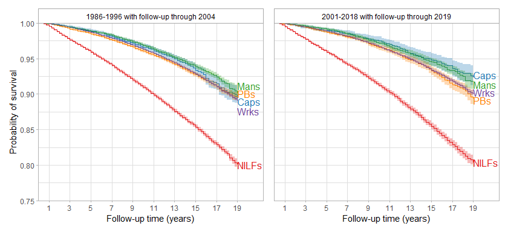

```r
plotted(kapped_early) +
  facet_wrap(~period) +
  scale_y_continuous(limits=c(0.75, 1.0), expand=expansion(mult=c(0,0))) +
  scale_x_continuous(limits=c(0, 19), breaks=seq(1, 19, 2), expand=expansion(mult=c(0,0.13))) +
  theme(panel.grid.minor.x = element_blank(), strip.background=element_rect(color="darkgrey", fill=NA), strip.text=element_text(color="black")) +
plotted(kapped_late) +
  facet_wrap(~period) +
  scale_y_continuous(limits=c(0.75, 1.0), expand=expansion(mult=c(0,0))) +
  scale_x_continuous(limits=c(0, 19), breaks=seq(1, 19, 2), expand=expansion(mult=c(0,0.13))) +
  theme(panel.grid.minor.x = element_blank(), strip.background=element_rect(color="darkgrey", fill=NA), strip.text=element_text(color="black"),
        axis.title.y=element_blank(), axis.text.y=element_blank(), axis.ticks.y=element_blank())
```

```r
ggsave("change_over_time_adj.png", dpi=600, height=4, width=8.75)
```

#### IPW survival difference and hazard ratio

```r
tidy_n(modded=mod_early, bind=binded_early, captioned="Ref: capitalists (1986-1996 subset)")
```

Ref: capitalists (1986-1996 subset)

|  | HR | HR Lower | HR Upper | SD per 100 at end of f/u SD | SD per 100 at end of f/u Lower | SD per 100 at end of f/u Upper | N |
| --- | --- | --- | --- | --- | --- | --- | --- |
| classPBs | 1.09 | 0.98 | 1.21 | 0.3 | -1.3 | 2.0 | 563866 |
| classMans | 0.92 | 0.82 | 1.03 | 0.8 | -1.0 | 2.6 |  |
| classWrks | 1.07 | 0.97 | 1.19 | -0.2 | -1.8 | 1.4 |  |
| classNILFs | 2.33 | 2.11 | 2.58 | -9.2 | -10.9 | -7.5 |  |

```r
tidy_n(modded=mod_late, bind=binded_late, captioned="Ref: capitalists (2001-2018 subset)")
```

Ref: capitalists (2001-2018 subset)

|  | HR | HR Lower | HR Upper | SD per 100 at end of f/u SD | SD per 100 at end of f/u Lower | SD per 100 at end of f/u Upper | N |
| --- | --- | --- | --- | --- | --- | --- | --- |
| classPBs | 1.31 | 1.09 | 1.57 | -3.0 | -4.8 | -1.2 | 347473 |
| classMans | 1.04 | 0.86 | 1.25 | -0.6 | -2.4 | 1.2 |  |
| classWrks | 1.26 | 1.07 | 1.49 | -2.3 | -3.9 | -0.8 |  |
| classNILFs | 3.13 | 2.66 | 3.69 | -12.0 | -13.6 | -10.4 |  |

## Class-by-gender interaction

### Distribution of IPW

```r
dat_sub_no_hisp %>%
  filter(!is.na(class_gender) & !is.na(age)) %>%
  mutate(sw=ipwpoint(exposure=class_gender,
                     family="multinomial",
                     link="logit",
                     numerator=~1,
                     denominator=~rcs(age, 3) + rcs(year, 5),
                     data = subset(dat_sub_no_hisp, !is.na(class_gender) & !is.na(age)),
                     weights=mortwt_f,
                     maxit=1000,
                     trace=FALSE)$ipw.weights,
         sw_f=sw*mortwt_f,
         gender=ifelse(sex=="female", "Women", "Men"))  -> dat_sub_no_hisp_gender

summary(dat_sub_no_hisp_gender$sw)
```

```
##    Min. 1st Qu.  Median    Mean 3rd Qu.    Max.
##  0.2658  0.8753  0.9496  0.9961  1.0876  3.7876
```

```r
#easier for plotting purposes to make separate fits for each gender
kapped <- survfit(Surv(time,dead)~class_gender, robust=T, w=sw_f, data=dat_sub_no_hisp_gender, se=T)
kapped_men <- survfit(Surv(time,dead)~class + gender, robust=T, w=sw_f, data=subset(dat_sub_no_hisp_gender, gender=="Men"), se=T)
kapped_women <- survfit(Surv(time,dead)~class + gender, robust=T, w=sw_f, data=subset(dat_sub_no_hisp_gender, gender=="Women"), se=T)

mod <- coxph(Surv(time,dead)~class_gender, robust=T, w=sw_f, data=dat_sub_no_hisp_gender)
binded <- survdiffed_group()
```

### IPW survival plot

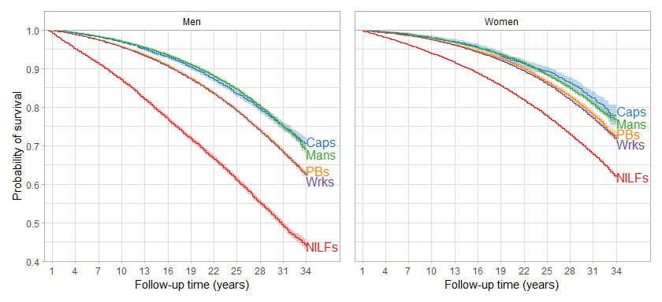

```r
plotted(kapped_men, bottom=0.4) +
  facet_wrap(~gender) +
  scale_x_continuous(limits=c(0, 34), breaks=seq(1, 34, 3), expand=expansion(mult=c(0,0.13))) +
  theme(panel.grid.minor.x = element_blank(), strip.background=element_rect(color="darkgrey", fill=NA), strip.text=element_text(color="black")) +
plotted(kapped_women, bottom=0.4) +
  facet_wrap(~gender) +
  scale_x_continuous(limits=c(0, 34), breaks=seq(1, 34, 3), expand=expansion(mult=c(0,0.13))) +
  theme(panel.grid.minor.x = element_blank(), strip.background=element_rect(color="darkgrey", fill=NA), strip.text=element_text(color="black"),
        axis.title.y=element_blank(), axis.text.y=element_blank(), axis.ticks.y=element_blank())
```

```r
ggsave("gender_survival.png", dpi=600, height=4, width=8.75)
```

### IPW survival difference and hazard ratio

```r
tidy_n(rows=1:9, nad=8, captioned="Ref: male capitalist")
```

Ref: male capitalist

|  | HR | HR Lower | HR Upper | SD per 100 at end of f/u SD | SD per 100 at end of f/u Lower | SD per 100 at end of f/u Upper | N |
| --- | --- | --- | --- | --- | --- | --- | --- |
| class_genderMale PBs | 1.33 | 1.25 | 1.42 | -6.2 | -7.5 | -5.0 | 921082 |
| class_genderMale mans | 0.97 | 0.91 | 1.03 | 0.2 | -1.0 | 1.5 |  |
| class_genderMale wrks | 1.34 | 1.27 | 1.42 | -6.3 | -7.4 | -5.2 |  |
| class_genderMale NILFs | 3.07 | 2.89 | 3.26 | -25.3 | -26.6 | -23.9 |  |
| class_genderFemale caps | 0.66 | 0.59 | 0.74 | 7.2 | 5.3 | 9.0 |  |
| class_genderFemale PBs | 0.83 | 0.78 | 0.89 | 3.2 | 1.9 | 4.5 |  |
| class_genderFemale mans | 0.70 | 0.66 | 0.75 | 5.7 | 4.5 | 6.9 |  |
| class_genderFemale wrks | 0.87 | 0.82 | 0.92 | 2.2 | 1.1 | 3.3 |  |
| class_genderFemale NILFs | 1.49 | 1.41 | 1.58 | -7.0 | -8.1 | -5.9 |  |

## Class-by-racialized-group interaction

### Distribution of IPW

```r
dat_sub_no_hisp %>%
  filter(!is.na(class_poc) & !is.na(age)) %>%
  mutate(sw=ipwpoint(exposure=class_poc,
                     family="multinomial",
                     link="logit",
                     numerator=~1,
                     denominator=~rcs(age, 3) + rcs(year, 5),
                     data = subset(dat_sub_no_hisp, !is.na(class_poc) & !is.na(age)),
                     weights=mortwt_f,
                     maxit=1000,
                     trace=FALSE)$ipw.weights,
         sw_f=sw*mortwt_f)  -> dat_sub_no_hisp_race_poc

summary(dat_sub_no_hisp_race_poc$sw)
```

```
##    Min. 1st Qu.  Median    Mean 3rd Qu.    Max.
##  0.3174  0.8439  0.9381  1.0061  1.1241  6.1821
```

```r
#easier for plotting purposes to make separate fits for each racialized group
kapped <- survfit(Surv(time,dead)~class_poc, robust=T, w=sw_f, data=dat_sub_no_hisp_race_poc, se=T)
kapped_white <- survfit(Surv(time,dead)~class + poc, robust=T, w=sw_f, data=subset(dat_sub_no_hisp_race_poc, poc=="NH white"), se=T)
kapped_poc <- survfit(Surv(time,dead)~class + poc, robust=T, w=sw_f, data=subset(dat_sub_no_hisp_race_poc,  poc=="POC"), se=T)

mod <- coxph(Surv(time,dead)~class_poc, robust=T, w=sw_f, data=dat_sub_no_hisp_race_poc)
binded <- survdiffed_group()
```

### IPW survival plot

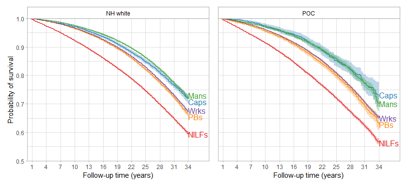

```r
plotted(kapped_white) +
  facet_wrap(~poc) +
  scale_x_continuous(limits=c(0, 34), breaks=seq(1, 34, 3), expand=expansion(mult=c(0,0.13))) +
  theme(panel.grid.minor.x = element_blank(), strip.background=element_rect(color="darkgrey", fill=NA), strip.text=element_text(color="black")) +
plotted(kapped_poc) +
  facet_wrap(~poc) +
  scale_x_continuous(limits=c(0, 34), breaks=seq(1, 34, 3), expand=expansion(mult=c(0,0.13))) +
  theme(panel.grid.minor.x = element_blank(), strip.background=element_rect(color="darkgrey", fill=NA), strip.text=element_text(color="black"),
        axis.title.y=element_blank(), axis.text.y=element_blank(), axis.ticks.y=element_blank())
```

```r
ggsave("race_survival.png", dpi=600, height=4, width=8.75)
```

### IPW survival difference and hazard ratio

```r
tidy_n(rows=1:9, nad=8, captioned="Ref: NH white capitalist")
```

Ref: NH white capitalist

|  | HR | HR Lower | HR Upper | SD per 100 at end of f/u SD | SD per 100 at end of f/u Lower | SD per 100 at end of f/u Upper | N |
| --- | --- | --- | --- | --- | --- | --- | --- |
| class_pocNH white PBs | 1.21 | 1.14 | 1.28 | -3.9 | -5.0 | -2.8 | 917350 |
| class_pocNH white mans | 0.91 | 0.86 | 0.97 | 1.1 | 0.0 | 2.2 |  |
| class_pocNH white wrks | 1.16 | 1.10 | 1.23 | -3.2 | -4.1 | -2.2 |  |
| class_pocNH white NILFs | 1.91 | 1.80 | 2.02 | -11.5 | -12.5 | -10.4 |  |
| class_pocPOC caps | 0.92 | 0.80 | 1.05 | 2.3 | -0.3 | 4.9 |  |
| class_pocPOC PBs | 1.38 | 1.28 | 1.50 | -6.7 | -8.5 | -5.0 |  |
| class_pocPOC mans | 0.96 | 0.89 | 1.04 | 0.9 | -0.7 | 2.6 |  |
| class_pocPOC wrks | 1.30 | 1.23 | 1.38 | -5.5 | -6.5 | -4.4 |  |
| class_pocPOC NILFs | 2.12 | 2.01 | 2.25 | -14.0 | -15.1 | -12.8 |  |

## Class-by-education interaction

### Distribution of IPW

```r
dat_sub_no_hisp %>%
  filter(!is.na(class_educ) & !is.na(age)) %>%
  mutate(less_educ=ifelse(educ=="<HS" | educ=="HS", "HS or less", "Some college or more"),
         sw=ipwpoint(exposure=class_educ,
                     family="multinomial",
                     link="logit",
                     numerator=~1,
                     denominator=~rcs(age, 3) + rcs(year, 5),
                     data = subset(dat_sub_no_hisp, !is.na(class_educ) & !is.na(age)),
                     weights=mortwt_f,
                     maxit=1000,
                     trace=FALSE)$ipw.weights,
         sw_f=sw*mortwt_f)  -> dat_sub_no_hisp_educ

summary(dat_sub_no_hisp_educ$sw)
```

```
##    Min. 1st Qu.  Median    Mean 3rd Qu.    Max.
##  0.3095  0.7613  0.9530  0.9950  1.1657  4.2306
```

```r
#easier for plotting purposes to make separate fits for each racialized group
kapped <- survfit(Surv(time,dead)~class_educ, robust=T, w=sw_f, data=dat_sub_no_hisp_educ, se=T)
kapped_less <- survfit(Surv(time,dead)~class + less_educ, robust=T, w=sw_f, data=subset(dat_sub_no_hisp_educ, less_educ=="HS or less"), se=T)
kapped_more <- survfit(Surv(time,dead)~class + less_educ, robust=T, w=sw_f, data=subset(dat_sub_no_hisp_educ, less_educ=="Some college or more"), se=T)

mod <- coxph(Surv(time,dead)~class_educ, robust=T, w=sw_f, data=dat_sub_no_hisp_educ)
binded <- survdiffed_group()
```

### IPW survival plot

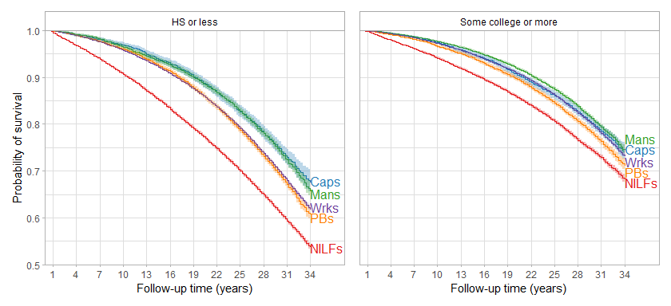

```r
plotted(kapped_less) +
  facet_wrap(~less_educ) +
  scale_x_continuous(limits=c(0, 34), breaks=seq(1, 34, 3), expand=expansion(mult=c(0,0.13))) +
  theme(panel.grid.minor.x = element_blank(), strip.background=element_rect(color="darkgrey", fill=NA), strip.text=element_text(color="black")) +
plotted(kapped_more) +
  facet_wrap(~less_educ) +
  scale_x_continuous(limits=c(0, 34), breaks=seq(1, 34, 3), expand=expansion(mult=c(0,0.13))) +
  theme(panel.grid.minor.x = element_blank(), strip.background=element_rect(color="darkgrey", fill=NA), strip.text=element_text(color="black"),
        axis.title.y=element_blank(), axis.text.y=element_blank(), axis.ticks.y=element_blank())
```

```r
ggsave("educ_survival.png", dpi=600, height=4, width=8.75)
```

### IPW survival difference and hazard ratio

```r
tidy_n(rows=1:9, nad=8, captioned="Ref: >HS capitalists")
```

Ref: >HS capitalists

|  | HR | HR Lower | HR Upper | SD per 100 at end of f/u SD | SD per 100 at end of f/u Lower | SD per 100 at end of f/u Upper | N |
| --- | --- | --- | --- | --- | --- | --- | --- |
| class_educ>HS PBs | 1.15 | 1.07 | 1.24 | -2.1 | -3.4 | -0.8 | 916036 |
| class_educ>HS mans | 0.92 | 0.86 | 0.99 | 0.9 | -0.2 | 2.1 |  |
| class_educ>HS wrks | 1.02 | 0.96 | 1.09 | -0.3 | -1.4 | 0.8 |  |
| class_educ>HS NILFs | 1.54 | 1.44 | 1.64 | -5.8 | -7.0 | -4.6 |  |
| class_educ=HS caps | 1.27 | 1.15 | 1.40 | -5.0 | -6.9 | -3.1 |  |
| class_educ=HS PBs | 1.59 | 1.48 | 1.71 | -10.6 | -12.0 | -9.3 |  |
| class_educ=HS mans | 1.30 | 1.20 | 1.41 | -5.5 | -6.9 | -4.1 |  |
| class_educ=HS wrks | 1.59 | 1.49 | 1.69 | -10.0 | -11.1 | -8.9 |  |
| class_educ=HS NILFs | 2.56 | 2.40 | 2.73 | -18.7 | -19.8 | -17.5 |  |

## Class-by-age stratification - 25-44 vs 45-64 years old

### Distribution of IPW

#### 25-44

```r
dat_sub_no_hisp %>%
  filter(age<45 & !is.na(class) & !is.na(age)) %>%
  mutate(sw=ipwpoint(exposure=class,
                     family="multinomial",
                     link="logit",
                     numerator=~1,
                     denominator=~rcs(age, 3) + sex + rcs(year, 5),
                     data = subset(dat_sub_no_hisp, age<45 & !is.na(class) & !is.na(age)),
                     weights=mortwt_f,
                     maxit=1000,
                     trace=FALSE)$ipw.weights,
         sw_f=sw*mortwt_f,
         age_cat="25-44")  -> dat_sub_no_hisp_young

summary(dat_sub_no_hisp_young$sw)
```

```
##    Min. 1st Qu.  Median    Mean 3rd Qu.    Max.
##  0.3810  0.8654  0.9760  0.9968  1.1063  7.6903
```

#### 45-64

```r
dat_sub_no_hisp %>%
  filter(age>=45 & !is.na(class) & !is.na(age)) %>%
  mutate(sw=ipwpoint(exposure=class,
                     family="multinomial",
                     link="logit",
                     numerator=~1,
                     denominator=~rcs(age, 3) + sex + rcs(year, 5),
                     data = subset(dat_sub_no_hisp, age>=45 & !is.na(class) & !is.na(age)),
                     weights=mortwt_f,
                     maxit=1000,
                     trace=FALSE)$ipw.weights,
         sw_f=sw*mortwt_f,
         age_cat="45-64")  -> dat_sub_no_hisp_old

summary(dat_sub_no_hisp_old$sw)
```

```
##    Min. 1st Qu.  Median    Mean 3rd Qu.    Max.
##  0.3962  0.8362  0.9151  0.9928  1.1014  3.4053
```

```r
#young
kapped_young <- survfit(Surv(time,dead)~class + age_cat, robust=T, w=sw_f, data=dat_sub_no_hisp_young, se=T) #age allows for faceting but doesnt affect ests
mod_young <- coxph(Surv(time,dead)~class, robust=T, w=sw_f, data=dat_sub_no_hisp_young)
binded_young <- survdiffed(kapped_young)

#old
kapped_old <- survfit(Surv(time,dead)~class + age_cat, robust=T, w=sw_f, data=dat_sub_no_hisp_old, se=T)
mod_old <- coxph(Surv(time,dead)~class, robust=T, w=sw_f, data=dat_sub_no_hisp_old)
binded_old <- survdiffed(kapped_old)
```

### IPW survival plots

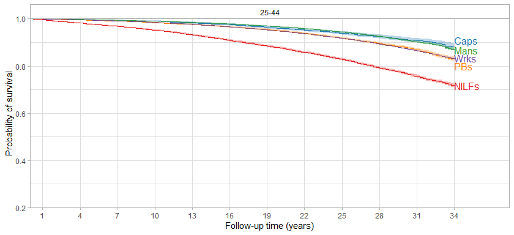

```r
plotted(kapped_young) +
  facet_wrap(~age_cat) +
  scale_y_continuous(limits=c(0.2, 1.0), expand=expansion(mult=c(0,0))) +
  scale_x_continuous(limits=c(0, 34), breaks=seq(1, 34, 3), expand=expansion(mult=c(0,0.13))) +
  theme(panel.grid.minor.x = element_blank(), strip.background=element_rect(color="darkgrey", fill=NA), strip.text=element_text(color="black")) #+
```

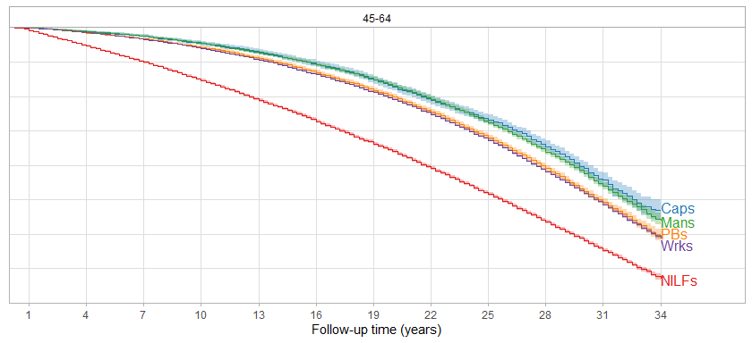

```r
plotted(kapped_old) +
  facet_wrap(~age_cat) +
  scale_y_continuous(limits=c(0.2, 1.0), expand=expansion(mult=c(0,0))) +
  scale_x_continuous(limits=c(0, 34), breaks=seq(1, 34, 3), expand=expansion(mult=c(0,0.13))) +
  theme(panel.grid.minor.x = element_blank(), strip.background=element_rect(color="darkgrey", fill=NA), strip.text=element_text(color="black"),
        axis.title.y=element_blank(), axis.text.y=element_blank(), axis.ticks.y=element_blank())
```

```r
ggsave("age_survival.png", dpi=600, height=4, width=8.75)
```

### IPW survival difference and hazard ratio

```r
tidy_n(modded=mod_young, bind=binded_young, captioned="Ref: capitalists (25-44 subset)")
```

Ref: capitalists (25-44 subset)

|  | HR | HR Lower | HR Upper | SD per 100 at end of f/u SD | SD per 100 at end of f/u Lower | SD per 100 at end of f/u Upper | N |
| --- | --- | --- | --- | --- | --- | --- | --- |
| classPBs | 1.42 | 1.25 | 1.62 | -5.3 | -7.1 | -3.4 | 533757 |
| classMans | 0.98 | 0.87 | 1.11 | -1.0 | -2.8 | 0.7 |  |
| classWrks | 1.43 | 1.27 | 1.62 | -5.2 | -6.8 | -3.6 |  |
| classNILFs | 3.20 | 2.83 | 3.62 | -16.4 | -18.2 | -14.7 |  |

```r
tidy_n(modded=mod_old, bind=binded_old, captioned="Ref: capitalists (45-64 subset)")
```

Ref: capitalists (45-64 subset)

|  | HR | HR Lower | HR Upper | SD per 100 at end of f/u SD | SD per 100 at end of f/u Lower | SD per 100 at end of f/u Upper | N |
| --- | --- | --- | --- | --- | --- | --- | --- |
| classPBs | 1.23 | 1.15 | 1.31 | -7.6 | -10.9 | -4.2 | 387325 |
| classMans | 1.03 | 0.97 | 1.10 | -3.2 | -6.6 | 0.2 |  |
| classWrks | 1.27 | 1.20 | 1.34 | -8.3 | -11.3 | -5.3 |  |
| classNILFs | 2.38 | 2.24 | 2.52 | -20.0 | -23.0 | -16.9 |  |

## Subdividing workers

### Distribution of IPW

Truncated at 0.5% and 99.5%.

```r
dat_sub_no_hisp %>%
  filter(!is.na(class_occ) & !is.na(age)) %>%
  mutate(sw=ipwpoint(exposure=class_occ,
                     family="multinomial",
                     link="logit",
                     numerator=~1,
                     denominator=~rcs(age, 3) + sex + rcs(year, 5),
                     data = subset(dat_sub_no_hisp, !is.na(class_occ) & !is.na(age)),
                     weights=mortwt_f,
                     trunc=0.005,
                     maxit=1000,
                     trace=FALSE)$weights.trunc,
         sw_f=sw*mortwt_f)  -> dat_sub_no_hisp_class_occ

summary(dat_sub_no_hisp_class_occ$sw)
```

```
##    Min. 1st Qu.  Median    Mean 3rd Qu.    Max.
##  0.3439  0.7105  0.8663  0.9907  1.1581  3.5707
```

```r
kapped <- survfit(Surv(time,dead)~class_occ, robust=T, w=sw_f, data=dat_sub_no_hisp_class_occ, se=T)
mod <- coxph(Surv(time,dead)~class_occ, robust=T, w=sw_f, data=dat_sub_no_hisp_class_occ)
binded <- survdiffed_sub()
```

### IPW survival plot

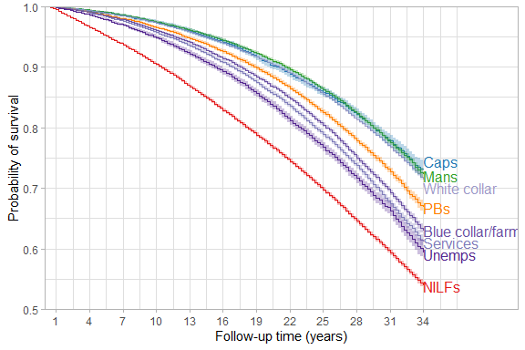

```r
survplot <- ggsurvplot(kapped,
                       size=0.35,
                       conf.int = T,
                       ylim=c(0.50, 1.0),
                       xlim=c(0, max(kapped$time)),
                       axes.offset=F,
                       censor=F)

survplot$plot +
  scale_color_manual(values=c(brewer.pal(n = 12, name = "Paired")[c(2,8,4)],
                              brewer.pal(n=9, name="Purples")[c(5,6,7,8)], brewer.pal(n = 12, name = "Paired")[c(6)])) +
  scale_fill_manual(values=c(brewer.pal(n = 12, name = "Paired")[c(2,8,4)],
                             brewer.pal(n=9, name="Purples")[c(5,6,7,8)], brewer.pal(n = 12, name = "Paired")[c(6)])) +
  geom_dl(aes(label=class_occ, group=strata, color=strata), method='last.qp') +
  scale_x_continuous(limits=c(0, 34), breaks=seq(1, 34, 3), expand=expansion(mult=c(0,0.25))) +
  scale_y_continuous(limits=c(0.5, 1.0), expand=expansion(mult=c(0,0))) +
  ylab("Probability of survival") +
  xlab("Follow-up time (years)") +
  theme_light() +
  theme(legend.position="none")
```

```r
ggsave("subdivided_workers_survival.png", dpi=600, height=4, width=6)
```

### IPW survival difference and hazard ratio

```r
tidy_n(rows=1:7, nad=6, captioned="Ref: capitalist")
```

Ref: capitalist

|  | HR | HR Lower | HR Upper | SD per 100 at end of f/u SD | SD per 100 at end of f/u Lower | SD per 100 at end of f/u Upper | N |
| --- | --- | --- | --- | --- | --- | --- | --- |
| class_occPBs | 1.27 | 1.20 | 1.35 | -4.7 | -5.8 | -3.6 | 921082 |
| class_occMans | 0.98 | 0.93 | 1.04 | 0.0 | -1.1 | 1.0 |  |
| class_occWhite collar | 1.04 | 0.99 | 1.10 | -0.8 | -1.8 | 0.1 |  |
| class_occServices | 1.56 | 1.48 | 1.65 | -9.7 | -10.8 | -8.6 |  |
| class_occBlue collar/farm | 1.46 | 1.38 | 1.54 | -7.9 | -9.0 | -6.9 |  |
| class_occUnemps | 1.75 | 1.64 | 1.86 | -11.2 | -12.5 | -9.9 |  |
| class_occNILFs | 2.55 | 2.41 | 2.69 | -18.2 | -19.2 | -17.1 |  |

## Sensitivity analyses

### Regression adjustment instead of IPW for minimally-adjusted overall Cox analyses

Similar to primary but slightly larger effect sizes for workers and PBs.

```r
mod <- coxph(Surv(time,dead)~class + rcs(age, 3) + sex + rcs(year, 5), robust=T, w=mortwt_f, data=dat_sub_no_hisp_overall)

kable(cbind(tidy(mod, exponentiate=T, conf.int=T)[1:4, c(1,2,7,8)], c(length(mod$residuals), NA, NA, NA)),
      col.names=c(" ", "HR", "Lower", "Upper", "N"), caption="Ref: capitalist", digits=2) %>%
  kable_styling("striped")
```

Ref: capitalist

|  | HR | Lower | Upper | N |
| --- | --- | --- | --- | --- |
| classPBs | 1.32 | 1.26 | 1.38 | 921082 |
| classMans | 1.00 | 0.96 | 1.05 |  |
| classWrks | 1.36 | 1.30 | 1.42 |  |
| classNILFs | 2.48 | 2.37 | 2.60 |  |

### Confirming SEs make sense

#### Survey design for overall Cox analyses with IPW

Basically identical to primary. It makes no difference that we subsetted the dataset by age above rather than within the svycoxph function because age subpopulations appear in all the clusters

```r
dat_sub_no_hisp_svy <- svydesign(ids = ~ psu,
                         strata = ~ strata,
                         weights = ~ sw_f,
                         nest=TRUE,
                         data=dat_sub_no_hisp_overall)

mod <- svycoxph(Surv(time,dead)~class, design=subset(dat_sub_no_hisp_svy, !is.na(class) & !is.na(age)))

kable(cbind(tidy(mod, exponentiate=T, conf.int=T)[1:4, c(1,2,7,8)], c(length(mod$residuals), NA, NA, NA)),
      col.names=c(" ", "HR", "Lower", "Upper", "N"), caption="Ref: capitalist", digits=2) %>%
  kable_styling("striped")
```

```
## Stratified 1 - level Cluster Sampling design (with replacement)
## With (2575) clusters.
## subset(dat_sub_no_hisp_svy, !is.na(class) & !is.na(age))
```

Ref: capitalist

|  | HR | Lower | Upper | N |
| --- | --- | --- | --- | --- |
| classPBs | 1.28 | 1.21 | 1.36 | 921082 |
| classMans | 0.99 | 0.94 | 1.05 |  |
| classWrks | 1.30 | 1.23 | 1.37 |  |
| classNILFs | 2.57 | 2.43 | 2.72 |  |

#### Clustering SEs at household level

Also basically identical to primary.

```r
kapped <- survfit(Surv(time,dead)~class + cluster(nhishid), w=sw_f, data=dat_sub_no_hisp_overall, se=T)
mod <- coxph(Surv(time,dead)~class + cluster(nhishid), w=sw_f, data=dat_sub_no_hisp_overall)
binded <- survdiffed()
```

```r
tidy_n()
```

Ref: capitalist

|  | HR | HR Lower | HR Upper | SD per 100 at end of f/u SD | SD per 100 at end of f/u Lower | SD per 100 at end of f/u Upper | N |
| --- | --- | --- | --- | --- | --- | --- | --- |
| classPBs | 1.28 | 1.21 | 1.36 | -6.5 | -8.3 | -4.7 | 921082 |
| classMans | 0.99 | 0.94 | 1.05 | -1.1 | -2.8 | 0.6 |  |
| classWrks | 1.30 | 1.23 | 1.37 | -6.6 | -8.2 | -5.1 |  |
| classNILFs | 2.57 | 2.43 | 2.71 | -19.3 | -20.9 | -17.6 |  |

### Including Hispanic oversample to see effects on point estimates

Basically identical to primary.

#### Distribution of IPW

```r
dat_sub %>%
  filter(!is.na(class) & !is.na(age)) %>%
  mutate(sw=ipwpoint(exposure=class,
                     family="multinomial",
                     link="logit",
                     numerator=~1,
                     denominator=~rcs(age, 3) + sex + rcs(year, 5),
                     data = subset(dat_sub, !is.na(class) & !is.na(age)),
                     weights=mortwt_f,
                     maxit=1000,
                     trace=FALSE)$ipw.weights,
         sw_f=sw*mortwt_f)  -> dat_sub_hisp_overall

summary(dat_sub_hisp_overall$sw)
```

```
##    Min. 1st Qu.  Median    Mean 3rd Qu.    Max.
##  0.3347  0.8489  0.9532  0.9901  1.0505  6.2199
```

```r
kapped <- survfit(Surv(time,dead)~class, robust=T, w=sw_f, data=dat_sub_hisp_overall, se=T)
mod <- coxph(Surv(time,dead)~class, robust=T, w=sw_f, data=dat_sub_hisp_overall)
binded <- survdiffed()
```

#### IPW survival difference and hazard ratio

```r
tidy_n()
```

Ref: capitalist

|  | HR | HR Lower | HR Upper | SD per 100 at end of f/u SD | SD per 100 at end of f/u Lower | SD per 100 at end of f/u Upper | N |
| --- | --- | --- | --- | --- | --- | --- | --- |
| classPBs | 1.28 | 1.21 | 1.36 | -6.5 | -8.2 | -4.7 | 924438 |
| classMans | 0.99 | 0.94 | 1.05 | -1.1 | -2.8 | 0.6 |  |
| classWrks | 1.29 | 1.23 | 1.37 | -6.6 | -8.2 | -5.1 |  |
| classNILFs | 2.57 | 2.43 | 2.71 | -19.2 | -20.9 | -17.6 |  |

### Class by year interaction with regression adjustment instead of period stratification

Similar to primary.

#### Less-adjusted

```r
mod_1986 <- coxph(Surv(time,dead)~class*I(year - 1986) + rcs(age, 3) + sex, robust=T, w=mortwt_f, data=dat_sub_no_hisp_overall)
mod_2018 <- coxph(Surv(time,dead)~class*I(year - 2018) + rcs(age, 3) + sex, robust=T, w=mortwt_f, data=dat_sub_no_hisp_overall)

kable(cbind(tidy(mod_1986, exponentiate=T, conf.int=T)[1:4, c(1,2,7,8)],
            tidy(mod_2018, exponentiate=T, conf.int=T)[1:4, c(2,7,8)],
            c(length(mod_1986$residuals), NA, NA, NA)),
            col.names=c(" ", "HR", "Lower", "Upper", "HR", "Lower", "Upper", "N"),
      caption="Ref: capitalist in given year",
      digits=2) %>%
  kable_styling("striped") %>%
  add_header_above(c(" ", "HR in 1986"=3, "HR in 2018"=3, " "))
```

Ref: capitalist in given year

|  | HR in 1986 HR | HR in 1986 Lower | HR in 1986 Upper | HR in 2018 HR | HR in 2018 Lower | HR in 2018 Upper | N |
| --- | --- | --- | --- | --- | --- | --- | --- |
| classPBs | 1.26 | 1.18 | 1.34 | 1.45 | 1.14 | 1.84 | 921082 |
| classMans | 1.05 | 0.98 | 1.11 | 0.89 | 0.70 | 1.13 |  |
| classWrks | 1.31 | 1.24 | 1.38 | 1.52 | 1.23 | 1.88 |  |
| classNILFs | 1.91 | 1.80 | 2.02 | 4.59 | 3.72 | 5.68 |  |

#### More-adjusted

```r
mod_1986 <- coxph(Surv(time,dead)~class*I(year - 1986) + rcs(age, 3) + sex + educ + marital_tri + region + race_h, robust=T, w=mortwt_f, data=dat_sub_no_hisp_overall)
mod_2018 <- coxph(Surv(time,dead)~class*I(year - 2018) + rcs(age, 3) + sex + educ + marital_tri + region + race_h, robust=T, w=mortwt_f, data=dat_sub_no_hisp_overall)

kable(cbind(tidy(mod_1986, exponentiate=T, conf.int=T)[1:4, c(1,2,7,8)],
            tidy(mod_2018, exponentiate=T, conf.int=T)[1:4, c(2,7,8)],
            c(length(mod_1986$residuals), NA, NA, NA)),
            col.names=c(" ", "HR", "Lower", "Upper", "HR", "Lower", "Upper", "N"),
      caption="Ref: capitalist in given year",
      digits=2) %>%
  kable_styling("striped") %>%
  add_header_above(c(" ", "HR in 1986"=3, "HR in 2018"=3, " "))
```

Ref: capitalist in given year

|  | HR in 1986 HR | HR in 1986 Lower | HR in 1986 Upper | HR in 2018 HR | HR in 2018 Lower | HR in 2018 Upper | N |
| --- | --- | --- | --- | --- | --- | --- | --- |
| classPBs | 1.09 | 1.03 | 1.16 | 1.27 | 1.00 | 1.62 | 911339 |
| classMans | 1.04 | 0.98 | 1.11 | 0.93 | 0.73 | 1.18 |  |
| classWrks | 1.08 | 1.03 | 1.15 | 1.32 | 1.07 | 1.63 |  |
| classNILFs | 1.50 | 1.41 | 1.58 | 3.59 | 2.91 | 4.44 |  |

### Including employed “chief executives, general and operative managers, and legislators” in capitalist class rather than managerial class from 2005-2018

HR similar to 2001-2018 analysis above.

```r
dat_sub_no_hisp %>%
  filter(year>=2005) %>%
  mutate(ceo=ifelse(occ==1, 1, 0),
         class_ceo=factor(ifelse(empstat==220, "NILFs",
                                ifelse((empstat>=200 & empstat<=214) | (classwk2>=1 & classwk2<=4 & managers!=1  & ceo!=1), "Workers",
                                      ifelse(classwk2>=1 & classwk2<=4 & managers==1 & ceo!=1, "Managers",
                                            ifelse((classwk2==5 & jobsecincorp==2) | (classwk2>=1 & classwk2<=4 & managers==1 & ceo==1), "Capitalists",
                                                    ifelse((classwk2==6  & ceo!=1) | (classwk2==5 & jobsecincorp==1 & ceo!=1), "PBs", NA))))),
                          levels=c("Capitalists", "PBs", "Managers", "Workers", "NILFs"))) -> dat_sub_no_hisp_2005_ceo

dat_sub_no_hisp_2005_ceo %>%
  filter(!is.na(class_ceo) & !is.na(age)) %>%
  mutate(sw=ipwpoint(exposure=class_ceo,
                     family="multinomial",
                     link="logit",
                     numerator=~1,
                     denominator=~rcs(age, 3) + sex + rcs(year, 3),
                     data = subset(dat_sub_no_hisp_2005_ceo, !is.na(class_ceo) & !is.na(age)),
                     weights=mortwt_f,
                     maxit=1000,
                     trace=FALSE)$ipw.weights,
         sw_f=sw*mortwt_f)  -> dat_sub_no_hisp_2005_ceo

summary(dat_sub_no_hisp_2005_ceo$sw)
```

```
##    Min. 1st Qu.  Median    Mean 3rd Qu.    Max.
##  0.3666  0.8547  0.9402  0.9993  1.0786  5.4032
```

```r
kapped <- survfit(Surv(time,dead)~class, robust=T, w=sw_f, data=dat_sub_no_hisp_2005_ceo, se=T)
mod <- coxph(Surv(time,dead)~class, robust=T, w=sw_f, data=dat_sub_no_hisp_2005_ceo)
binded <- survdiffed(timed=15)
```

#### IPW survival difference and hazard ratio

```r
tidy_n()
```

Ref: capitalist

|  | HR | HR Lower | HR Upper | SD per 100 at end of f/u SD | SD per 100 at end of f/u Lower | SD per 100 at end of f/u Upper | N |
| --- | --- | --- | --- | --- | --- | --- | --- |
| classPBs | 1.28 | 1.00 | 1.64 | -1.2 | -2.8 | 0.3 | 268177 |
| classMans | 0.89 | 0.70 | 1.14 | 0.6 | -0.9 | 2.0 |  |
| classWrks | 1.32 | 1.06 | 1.65 | -1.6 | -2.9 | -0.2 |  |
| classNILFs | 4.00 | 3.20 | 4.99 | -11.4 | -12.9 | -9.8 |  |